# Energy analysis - Point to point arena

```r
library(tidyverse)
library(ggpubr)
library(rstatix)
library(lmPerm)
library(e1071)
library(DescTools)

capitalize <- function(string) {
  substr(string, 1, 1) <- toupper(substr(string, 1, 1))
  string
}
custom_theme <- theme_bw(base_size = 19) + theme(
  axis.line = element_line(colour = "black"),
  panel.border = element_blank(),
  legend.position = "top",
  text=element_text(family="serif"),
)
```

# Measurements

Let us first load all measurements obtained from the experiment.

```r
measurements <- read.csv("/home/engel/Documents/experiments/slam_experiment/run_table.csv")
measurements <- measurements[measurements$arena == 'point_to_point', ]
measurements$algorithm <- as.factor(measurements$algorithm)
measurements$map_resolution <- as.factor(measurements$map_resolution)
measurements$linear_update <- as.factor(measurements$linear_update)
measurements$angular_update <- as.factor(measurements$angular_update)
measurements$energy <- measurements$energy / 1000
measurements
```

|  | X__run_id | X__done | algorithm | arena | map_resolution | linear_update | angular_update | repetition | avg_cpu | avg_mem | energy | rosbag_msg_count | rosbag_msg_size |
| --- | --- | --- | --- | --- | --- | --- | --- | --- | --- | --- | --- | --- | --- |
| 1 | run_1 | DONE | hector | point_to_point | 0.1 | 1 | 0.0174 | 1 | 27.36720 | 780349041 | 811.6946 | 40713 | 3283512 |
| 2 | run_2 | DONE | gmapping | point_to_point | 0.1 | 0.2 | 0.0174 | 1 | 39.16658 | 650098819 | 836.5034 | 43282 | 3489688 |
| 3 | run_3 | DONE | cartographer | point_to_point | 0.1 | 1 | 0.0174 | 1 | 44.67624 | 686482165 | 822.1214 | 67732 | 4970488 |
| 4 | run_4 | DONE | hector | point_to_point | 0.05 | 0.2 | 0.9 | 1 | 29.95024 | 775278520 | 809.8360 | 39376 | 3176440 |
| 5 | run_5 | DONE | cartographer | point_to_point | 0.05 | 1 | 0.9 | 1 | 43.68501 | 687999163 | 812.6948 | 67045 | 4921248 |
| 6 | run_6 | DONE | hector | point_to_point | 0.05 | 1 | 0.9 | 1 | 29.03264 | 777044316 | 799.3648 | 39475 | 3184992 |
| 8 | run_8 | DONE | cartographer | point_to_point | 0.05 | 0.2 | 0.0174 | 1 | 49.58636 | 687764119 | 804.6217 | 61278 | 4457808 |
| 11 | run_11 | DONE | karto | point_to_point | 0.05 | 0.2 | 0.9 | 1 | 32.05339 | 651064187 | 802.8382 | 37752 | 3043656 |
| 12 | run_12 | DONE | cartographer | point_to_point | 0.1 | 1 | 0.0174 | 2 | 45.53550 | 688743415 | 815.4569 | 63412 | 4624096 |
| 13 | run_13 | DONE | cartographer | point_to_point | 0.1 | 1 | 0.0174 | 3 | 47.53162 | 689053720 | 813.0510 | 62672 | 4568368 |

[output cut: 150 more lines]

# Data exploration

Now, let us consider some descriptive statistics about the distribution of the measurements per group.

```r
measurements %>%
  group_by(algorithm, map_resolution, linear_update, angular_update) %>%
  get_summary_stats(energy, type = "full")
```

| algorithm | map_resolution | linear_update | angular_update | variable | n | min | max | median | q1 | q3 | iqr | mad | mean | sd | se | ci |
| --- | --- | --- | --- | --- | --- | --- | --- | --- | --- | --- | --- | --- | --- | --- | --- | --- |
| cartographer | 0.05 | 0.2 | 0.0174 | energy | 5 | 804.622 | 827.591 | 822.629 | 813.560 | 825.743 | 12.182 | 7.357 | 818.829 | 9.600 | 4.293 | 11.920 |
| cartographer | 0.05 | 0.2 | 0.9 | energy | 5 | 824.461 | 831.593 | 827.898 | 825.830 | 829.808 | 3.979 | 3.066 | 827.918 | 2.889 | 1.292 | 3.588 |
| cartographer | 0.05 | 1 | 0.0174 | energy | 5 | 812.992 | 828.545 | 827.639 | 827.081 | 827.935 | 0.854 | 0.828 | 824.839 | 6.643 | 2.971 | 8.249 |
| cartographer | 0.05 | 1 | 0.9 | energy | 5 | 812.695 | 833.485 | 828.605 | 828.588 | 830.218 | 1.630 | 2.391 | 826.718 | 8.089 | 3.618 | 10.044 |
| cartographer | 0.1 | 0.2 | 0.0174 | energy | 5 | 821.640 | 826.913 | 825.465 | 823.448 | 826.055 | 2.607 | 2.147 | 824.704 | 2.136 | 0.955 | 2.652 |
| cartographer | 0.1 | 0.2 | 0.9 | energy | 5 | 824.135 | 838.958 | 825.658 | 824.330 | 827.996 | 3.666 | 2.259 | 828.216 | 6.200 | 2.773 | 7.698 |
| cartographer | 0.1 | 1 | 0.0174 | energy | 5 | 813.051 | 833.912 | 822.121 | 815.457 | 827.515 | 12.058 | 9.881 | 822.411 | 8.579 | 3.837 | 10.652 |
| cartographer | 0.1 | 1 | 0.9 | energy | 5 | 818.736 | 826.721 | 822.726 | 822.624 | 826.270 | 3.646 | 5.255 | 823.415 | 3.244 | 1.451 | 4.027 |
| gmapping | 0.05 | 0.2 | 0.0174 | energy | 5 | 823.024 | 855.046 | 839.144 | 838.803 | 845.928 | 7.125 | 10.058 | 840.389 | 11.738 | 5.249 | 14.575 |
| gmapping | 0.05 | 0.2 | 0.9 | energy | 5 | 797.478 | 817.997 | 815.349 | 814.158 | 815.873 | 1.715 | 1.766 | 812.171 | 8.330 | 3.725 | 10.344 |

[output cut: 22 more lines]

```r
measurements %>%
  group_by(algorithm) %>%
  get_summary_stats(energy, type = "full")
```

| algorithm | variable | n | min | max | median | q1 | q3 | iqr | mad | mean | sd | se | ci |
| --- | --- | --- | --- | --- | --- | --- | --- | --- | --- | --- | --- | --- | --- |
| cartographer | energy | 40 | 804.622 | 838.958 | 825.942 | 822.628 | 827.950 | 5.323 | 3.891 | 824.631 | 6.582 | 1.041 | 2.105 |
| gmapping | energy | 40 | 787.603 | 855.046 | 818.595 | 810.210 | 839.843 | 29.632 | 24.404 | 824.167 | 17.160 | 2.713 | 5.488 |
| hector | energy | 40 | 799.365 | 821.977 | 807.303 | 805.203 | 809.756 | 4.553 | 3.653 | 807.419 | 3.863 | 0.611 | 1.235 |
| karto | energy | 40 | 789.650 | 823.203 | 807.148 | 805.044 | 810.330 | 5.286 | 4.312 | 807.344 | 5.203 | 0.823 | 1.664 |

And a histogram of the distribution of the power measurements, which will be the primary focus of this analysis.

```r
hist <- gghistogram(measurements, x = "energy", color = "algorithm", fill = "algorithm", palette='jco') + custom_theme + xlab('Energy (J)') + ylab('Count') + labs(color='Algorithm', fill='Algorithm')
```

```
Using `bins = 30` by default. Pick better value with the argument `bins`.
```

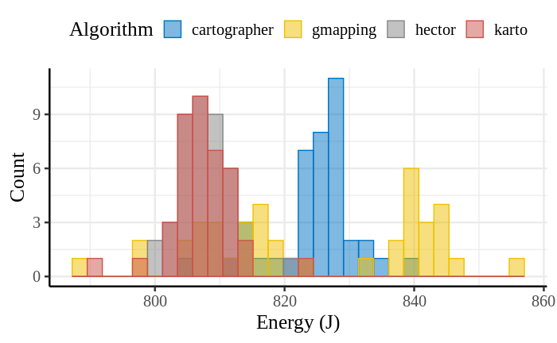

```r
hist
ggexport(hist, filename = "energy_point_to_point_histogram.pdf")
```

We notice the the gmapping measurements are very much spread out. The other measurements seem to be more clustered by algorithm.

To get an impression of the distribution of the distribution of average power per group, we plot the data in boxplots.

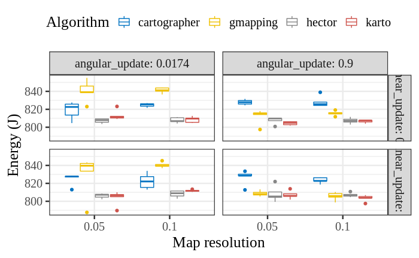

```r
bxp <- ggboxplot(measurements, x = "map_resolution", y = "energy", palette = "jco", color="algorithm", facet.by = c("linear_update", "angular_update"), labeller="label_both") + theme_bw(base_size = 19) + theme(legend.position="top", text=element_text(family="serif")) + xlab('Map resolution') + ylab('Energy (J)') + labs(color='Algorithm', fill='Algorithm')
bxp
ggexport(bxp, filename = "energy_point_to_point_box.pdf")
```

# ANOVA

## Assumption checking

ANOVA has four assumptions, which are checked in this section.

### 1. Independence of samples

By the design of the experiment, samples are independent (and fully randomised).

### 2. Normality of residuals

We fit a model based on all four factors (and their interactions) as parameters.

```r
model  <- lm(energy ~ algorithm*map_resolution*linear_update*angular_update, data = measurements)
res <- residuals(model)
```

Get an impression of the distribution of the residuals

```
Using `bins = 30` by default. Pick better value with the argument `bins`.
```

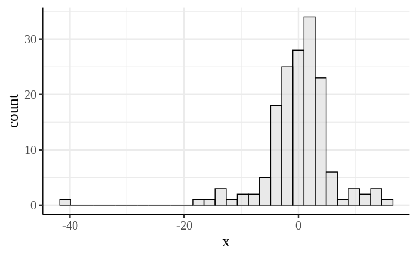

```r
gghistogram(res, fill="lightgrey") + custom_theme
```

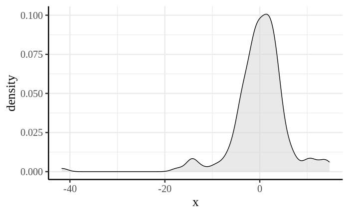

```r
ggdensity(res, fill="lightgrey") + custom_theme
```

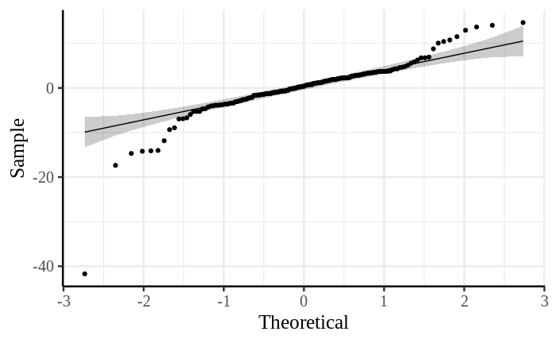

```r
# Create a QQ plot of residuals
ggqqplot(res) + custom_theme
```

```r
# Compute Shapiro-Wilk test of normality
shapiro_test(res)
```

| variable | statistic | p.value |
| --- | --- | --- |
| res | 0.8301284 | 2.362698e-12 |

```r
skewness(res)
```

```
[1] -2.157332
```

Not normal. Trying some transformations (sqrt, log, reciprocal) also gives no normal result.

### 3. Normality within groups

```r
shapiro_tests <- measurements %>% group_by(algorithm, map_resolution, linear_update, angular_update)  %>% shapiro_test(energy)
shapiro_tests[order(shapiro_tests$p),]
```

| algorithm | map_resolution | linear_update | angular_update | variable | statistic | p |
| --- | --- | --- | --- | --- | --- | --- |
| cartographer | 0.05 | 1 | 0.0174 | energy | 0.6296949 | 0.001511850 |
| gmapping | 0.05 | 1 | 0.0174 | energy | 0.6866901 | 0.006914174 |
| gmapping | 0.05 | 0.2 | 0.9 | energy | 0.7113270 | 0.012533529 |
| hector | 0.05 | 0.2 | 0.9 | energy | 0.7179143 | 0.014607513 |
| karto | 0.05 | 0.2 | 0.0174 | energy | 0.7308409 | 0.019589682 |
| cartographer | 0.1 | 0.2 | 0.9 | energy | 0.7498434 | 0.029663916 |
| karto | 0.05 | 1 | 0.0174 | energy | 0.7609139 | 0.037443935 |
| cartographer | 0.05 | 1 | 0.9 | energy | 0.7715705 | 0.046574040 |
| karto | 0.1 | 0.2 | 0.9 | energy | 0.7863134 | 0.062386005 |
| karto | 0.1 | 1 | 0.9 | energy | 0.8552604 | 0.211725950 |

[output cut: 22 more lines]

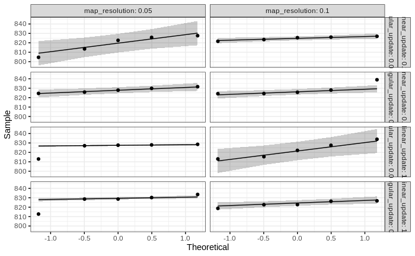

```r
ggqqplot(measurements[measurements$algorithm == 'cartographer', ], "energy", ggtheme = theme_bw()) + facet_grid( linear_update + angular_update ~ map_resolution, labeller = "label_both")
```

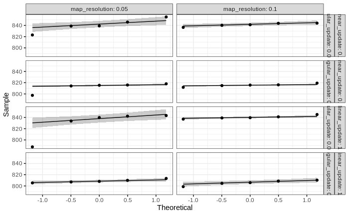

```r
ggqqplot(measurements[measurements$algorithm == 'gmapping', ], "energy", ggtheme = theme_bw()) + facet_grid(linear_update + angular_update ~ map_resolution, labeller = "label_both")
```

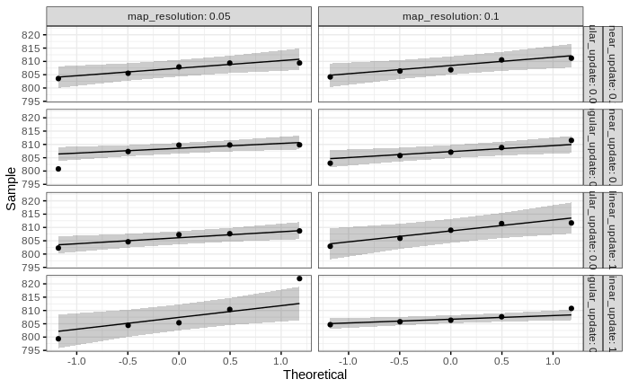

```r
ggqqplot(measurements[measurements$algorithm == 'hector', ], "energy", ggtheme = theme_bw()) + facet_grid(linear_update + angular_update ~ map_resolution, labeller = "label_both")
```

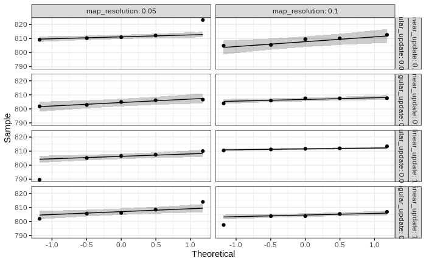

```r
ggqqplot(measurements[measurements$algorithm == 'karto', ], "energy", ggtheme = theme_bw()) + facet_grid(linear_update + angular_update ~ map_resolution, labeller = "label_both")
```

## 4. Homogeneity of variance

```r
levene_test(energy ~ algorithm*map_resolution*angular_update*linear_update, data = measurements)
```

| df1 | df2 | statistic | p |
| --- | --- | --- | --- |
| 31 | 128 | 0.9519001 | 0.5457217 |

The p-value is higher than 0.05, hence we fail to reject H0. Thus, we can assume homogeneity of variance among all groups.

It is important to note that one group has an extremely high variance (exceeding 2x the other variances).

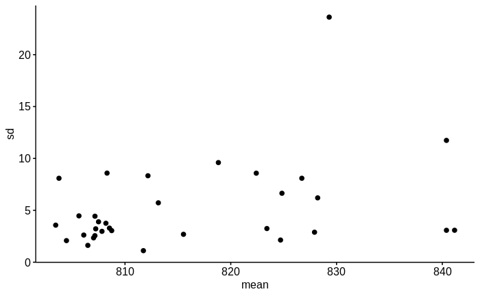

```r
agg_measurements <- measurements %>% group_by(algorithm, map_resolution, linear_update, angular_update) %>%
  get_summary_stats(energy, type = "mean_sd")
ggscatter(agg_measurements, "mean", "sd")
```

```r
agg_measurements[order(agg_measurements$sd),]
```

| algorithm | map_resolution | linear_update | angular_update | variable | n | mean | sd |
| --- | --- | --- | --- | --- | --- | --- | --- |
| karto | 0.1 | 1 | 0.0174 | energy | 5 | 811.740 | 1.112 |
| karto | 0.1 | 0.2 | 0.9 | energy | 5 | 806.488 | 1.621 |
| karto | 0.05 | 0.2 | 0.9 | energy | 5 | 804.467 | 2.080 |
| cartographer | 0.1 | 0.2 | 0.0174 | energy | 5 | 824.704 | 2.136 |
| hector | 0.1 | 1 | 0.9 | energy | 5 | 807.032 | 2.346 |
| hector | 0.05 | 0.2 | 0.0174 | energy | 5 | 807.157 | 2.556 |
| hector | 0.05 | 1 | 0.0174 | energy | 5 | 806.104 | 2.616 |
| gmapping | 0.1 | 0.2 | 0.9 | energy | 5 | 815.530 | 2.688 |
| cartographer | 0.05 | 0.2 | 0.9 | energy | 5 | 827.918 | 2.889 |
| hector | 0.1 | 0.2 | 0.0174 | energy | 5 | 807.824 | 2.974 |

[output cut: 22 more lines]

The assumptions for ANOVA are violated, hence we resort to PERMANOVA (using permutations).

## Running PERMANOVA

```r
set.seed(2031)
aovp.out <- aovp(energy ~ algorithm*map_resolution*linear_update*angular_update, data=measurements, maxIter=100000000, nCycle=1)
```

```
[1] "Settings:  unique SS "
```

```r
summary(aovp.out)
```

```
Component 1 :
                                                       Df R Sum Sq R Mean Sq      Iter Pr(Prob)
algorithm                                               3  11588.5    3862.8 100000000  < 2e-16 ***
map_resolution                                          1     37.3      37.3       115  0.46957
algorithm:map_resolution                                3     57.3      19.1        51  1.00000
linear_update                                           1    181.2     181.2      3634  0.02697 *
algorithm:linear_update                                 3    244.5      81.5      2316  0.12997
map_resolution:linear_update                            1      0.1       0.1        51  0.88235
algorithm:map_resolution:linear_update                  3    127.4      42.5       727  0.29161
angular_update                                          1   1839.2    1839.2 100000000  < 2e-16 ***
algorithm:angular_update                                3   5909.5    1969.8 100000000  < 2e-16 ***
map_resolution:angular_update                           1    117.3     117.3       920  0.09891 .
algorithm:map_resolution:angular_update                 3     20.2       6.7       309  0.87379
linear_update:angular_update                            1      2.6       2.6        66  0.60606
algorithm:linear_update:angular_update                  3     80.1      26.7        51  0.78431
map_resolution:linear_update:angular_update             1    168.4     168.4      1527  0.06156 .
algorithm:map_resolution:linear_update:angular_update   3    234.9      78.3      1648  0.19175
Residuals                                             128   5791.8      45.2
---
Signif. codes:  0 ‘***’ 0.001 ‘**’ 0.01 ‘*’ 0.05 ‘.’ 0.1 ‘ ’ 1
```

The results indicate a significant main effect of the algorithm, linear update and angular update factors.

There is also a significant interaction between the algorithm and angular update.

### Post hoc tests

Since there are only two treatments for the linear update (high and low) we do not need to perform a post hoc test for this main effect.

To analyse the main effect of the algorithm and angular update (interaction), we first assess normality of the groups and compare their variance.

```
Using `bins = 30` by default. Pick better value with the argument `bins`.
```

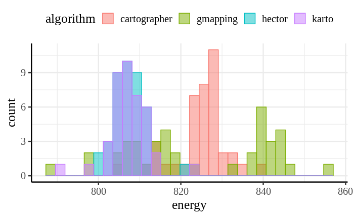

```r
gghistogram(measurements, 'energy', color="algorithm", fill="algorithm") + custom_theme
```

```r
shapiro_tests <- measurements %>% group_by(algorithm, angular_update)  %>% shapiro_test(energy)
shapiro_tests[order(shapiro_tests$p),]
```

| algorithm | angular_update | variable | statistic | p |
| --- | --- | --- | --- | --- |
| gmapping | 0.0174 | energy | 0.6368279 | 7.265912e-06 |
| karto | 0.0174 | energy | 0.8045462 | 1.010708e-03 |
| cartographer | 0.0174 | energy | 0.8832155 | 2.022193e-02 |
| hector | 0.9 | energy | 0.9009560 | 4.297780e-02 |
| karto | 0.9 | energy | 0.9370197 | 2.104943e-01 |
| gmapping | 0.9 | energy | 0.9422191 | 2.640012e-01 |
| cartographer | 0.9 | energy | 0.9584290 | 5.129633e-01 |
| hector | 0.0174 | energy | 0.9637517 | 6.211940e-01 |

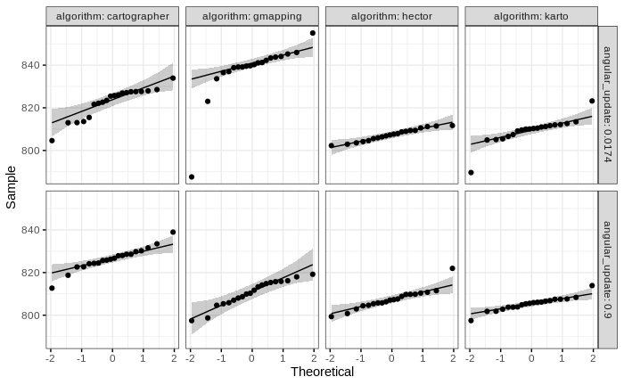

```r
ggqqplot(measurements, "energy", ggtheme = theme_bw()) + facet_grid(angular_update ~ algorithm, labeller = "label_both")
```

```r
levene_test(energy ~ algorithm, data = measurements)
```

| df1 | df2 | statistic | p |
| --- | --- | --- | --- |
| 3 | 156 | 40.79866 | 1.605469e-19 |

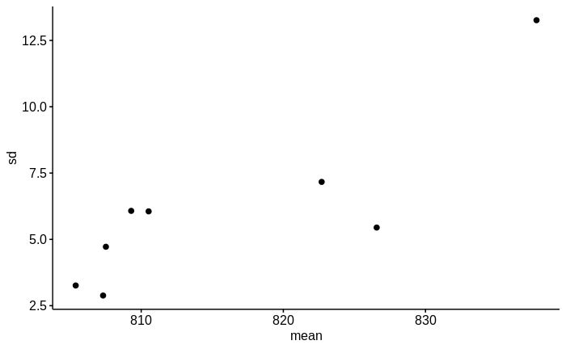

```r
agg_measurements <- measurements %>% group_by(algorithm, angular_update) %>%
  get_summary_stats(energy, type = "mean_sd")
ggscatter(agg_measurements, "mean", "sd")
```

```r
agg_measurements[order(agg_measurements$sd),]
```

| algorithm | angular_update | variable | n | mean | sd |
| --- | --- | --- | --- | --- | --- |
| hector | 0.0174 | energy | 20 | 807.320 | 2.883 |
| karto | 0.9 | energy | 20 | 805.392 | 3.262 |
| hector | 0.9 | energy | 20 | 807.517 | 4.722 |
| cartographer | 0.9 | energy | 20 | 826.567 | 5.446 |
| gmapping | 0.9 | energy | 20 | 810.523 | 6.056 |
| karto | 0.0174 | energy | 20 | 809.296 | 6.075 |
| cartographer | 0.0174 | energy | 20 | 822.696 | 7.167 |
| gmapping | 0.0174 | energy | 20 | 837.811 | 13.262 |

Both the normality of groups and heterogeneity of variance assumptions are violated, even after transformations. We therefore use the non-parametric Dunn’s test.

```r
algorithm_angular_update_interaction <- interaction(measurements$algorithm, measurements$angular_update)
DunnTest(energy ~ algorithm_angular_update_interaction, measurements, method='BH')
```

```
 Dunn's test of multiple comparisons using rank sums : BH

                                     mean.rank.diff    pval
gmapping.0.0174-cartographer.0.0174           29.20 0.07197 .
hector.0.0174-cartographer.0.0174            -64.50 2.7e-05 ***
karto.0.0174-cartographer.0.0174             -47.10 0.00261 **
cartographer.0.9-cartographer.0.0174          12.10 0.44034
gmapping.0.9-cartographer.0.0174             -43.15 0.00603 **
hector.0.9-cartographer.0.0174               -64.50 2.7e-05 ***
karto.0.9-cartographer.0.0174                -78.85 4.1e-07 ***
hector.0.0174-gmapping.0.0174                -93.70 1.5e-09 ***
karto.0.0174-gmapping.0.0174                 -76.30 6.7e-07 ***
cartographer.0.9-gmapping.0.0174             -17.10 0.29603
gmapping.0.9-gmapping.0.0174                 -72.35 2.5e-06 ***
hector.0.9-gmapping.0.0174                   -93.70 1.5e-09 ***
karto.0.9-gmapping.0.0174                   -108.05 4.6e-12 ***
karto.0.0174-hector.0.0174                    17.40 0.29603
cartographer.0.9-hector.0.0174                76.60 6.7e-07 ***
gmapping.0.9-hector.0.0174                    21.35 0.20309
hector.0.9-hector.0.0174                       0.00 1.00000
karto.0.9-hector.0.0174                      -14.35 0.36666
cartographer.0.9-karto.0.0174                 59.20 0.00012 ***
gmapping.0.9-karto.0.0174                      3.95 0.81664
hector.0.9-karto.0.0174                      -17.40 0.29603
karto.0.9-karto.0.0174                       -31.75 0.04980 *
gmapping.0.9-cartographer.0.9                -55.25 0.00035 ***
hector.0.9-cartographer.0.9                  -76.60 6.7e-07 ***
karto.0.9-cartographer.0.9                   -90.95 3.8e-09 ***
hector.0.9-gmapping.0.9                      -21.35 0.20309
karto.0.9-gmapping.0.9                       -35.70 0.02594 *
karto.0.9-hector.0.9                         -14.35 0.36666
---
Signif. codes:  0 '***' 0.001 '**' 0.01 '*' 0.05 '.' 0.1 ' ' 1
```